# W07-59071503-DUWei

1. Use the credictcard-reduced.csv dataset (Data description) and build Five classification models. Please plot confusion matrix, and evaluate your model performance using accuracy, precision, recall, F-score (70 points). A list of classification models can be found here¶
2. Illustrate the differences between these classifiers and compare the model performances. (30 points)

why models work and why does not work

3. Bonus credits (extra 0.5/100 points to Final GPA calculation):

Learn from the documentation for imbalanced classification and use any of the sampling methods to deal with the credictcard-reduced.csv dataset. Evaluate model performance before and after sampling.

#### 1. Use the credictcard-reduced.csv dataset (Data description) and build Five classification models. Please plot confusion matrix, and evaluate your model performance using accuracy, precision, recall, F-score.

```python
from sklearn.model_selection import train_test_split
import matplotlib.pyplot as plt
from sklearn.metrics import accuracy_score, precision_score, recall_score, f1_score
import pandas as pd
import numpy as np
from sklearn.tree import DecisionTreeClassifier
from sklearn.metrics import ConfusionMatrixDisplay

data = pd.read_csv('C:\\Users\\DD\\Desktop\\BIS\\6400\\W07\\creditcard-reduced.csv',header='infer')
data.head(5)
```

|  | Time | V1 | V2 | V3 | V4 | V5 | V6 | V7 | V8 | V9 | ... | V21 | V22 | V23 | V24 | V25 | V26 | V27 | V28 | Amount | Class |
| --- | --- | --- | --- | --- | --- | --- | --- | --- | --- | --- | --- | --- | --- | --- | --- | --- | --- | --- | --- | --- | --- |
| 0 | 406 | -2.312227 | 1.951992 | -1.609851 | 3.997906 | -0.522188 | -1.426545 | -2.537387 | 1.391657 | -2.770089 | ... | 0.517232 | -0.035049 | -0.465211 | 0.320198 | 0.044519 | 0.177840 | 0.261145 | -0.143276 | 0.00 | 1 |
| 1 | 472 | -3.043541 | -3.157307 | 1.088463 | 2.288644 | 1.359805 | -1.064823 | 0.325574 | -0.067794 | -0.270953 | ... | 0.661696 | 0.435477 | 1.375966 | -0.293803 | 0.279798 | -0.145362 | -0.252773 | 0.035764 | 529.00 | 1 |
| 2 | 4462 | -2.303350 | 1.759247 | -0.359745 | 2.330243 | -0.821628 | -0.075788 | 0.562320 | -0.399147 | -0.238253 | ... | -0.294166 | -0.932391 | 0.172726 | -0.087330 | -0.156114 | -0.542628 | 0.039566 | -0.153029 | 239.93 | 1 |
| 3 | 6986 | -4.397974 | 1.358367 | -2.592844 | 2.679787 | -1.128131 | -1.706536 | -3.496197 | -0.248778 | -0.247768 | ... | 0.573574 | 0.176968 | -0.436207 | -0.053502 | 0.252405 | -0.657488 | -0.827136 | 0.849573 | 59.00 | 1 |
| 4 | 7519 | 1.234235 | 3.019740 | -4.304597 | 4.732795 | 3.624201 | -1.357746 | 1.713445 | -0.496358 | -1.282858 | ... | -0.379068 | -0.704181 | -0.656805 | -1.632653 | 1.488901 | 0.566797 | -0.010016 | 0.146793 | 1.00 | 1 |

5 rows × 31 columns

```python
print(data.isnull().sum())
print(data['Class'].value_counts())
```

```
Time      0
V1        0
V2        0
V3        0
V4        0
V5        0
V6        0
V7        0
V8        0
V9        0
V10       0
V11       0
V12       0
V13       0
V14       0
V15       0
V16       0
V17       0
V18       0
V19       0
V20       0
V21       0
V22       0
V23       0
V24       0
V25       0
V26       0
V27       0
V28       0
Amount    0
Class     0
dtype: int64
Class
0    32272
1      492
Name: count, dtype: int64
```

```python
from sklearn.preprocessing import StandardScaler

data['Amount'] = StandardScaler().fit_transform(data['Amount'].values.reshape(-1, 1))
data['Time'] = StandardScaler().fit_transform(data['Time'].values.reshape(-1, 1))
```

```python
X = data.drop('Class', axis=1)
Y = data['Class']

X_train, X_test, Y_train, Y_test = train_test_split(X, Y, test_size=0.4, random_state=24)
```

#### 1.1 Decision Tree Classifier

```python
from sklearn.tree import DecisionTreeClassifier
clf = DecisionTreeClassifier(max_depth=2) # number estimators is the key parameter
clf = clf.fit(X_train, Y_train)
Y_predTrain = clf.predict(X_train)
Y_predTest = clf.predict(X_test)
```

[output not shown]

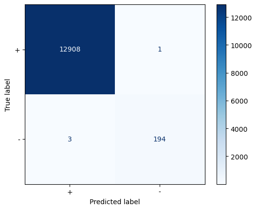

```python
from sklearn.metrics import ConfusionMatrixDisplay
import numpy as np

print('Training accuracy is %f' % accuracy_score(Y_train, Y_predTrain))
print('Validation accuracy is %f' %accuracy_score(Y_test, Y_predTest))
print('Training precision is %f' % precision_score(Y_train, Y_predTrain))
print('Validation precision is %f' % precision_score(Y_test, Y_predTest))
print('Training recall is %f' % recall_score(Y_train, Y_predTrain))
print('Validation recall is %f' % recall_score(Y_test, Y_predTest))
print('Training F-score is %f' % f1_score(Y_train, Y_predTrain))
print('Validation F-score %f' % f1_score(Y_test, Y_predTest))

disp = ConfusionMatrixDisplay.from_estimator(clf, X_test, Y_test,display_labels=['+','-'],values_format = '.0f',cmap=plt.cm.Blues)
np.set_printoptions(precision=1)
print(disp.confusion_matrix)
```

#### 1.2 Random Forest

```python
from sklearn.ensemble import RandomForestClassifier
np.random.seed(1)
clf1 = RandomForestClassifier(max_depth=2,n_estimators=500)
clf1 = clf1.fit(X_train, Y_train)
Y_predTrain = clf1.predict(X_train)
Y_predTest = clf1.predict(X_test)
```

```
Training accuracy is 0.997558
Validation accuracy is 0.996948
Training precision is 1.000000
Validation precision is 0.993711
Training recall is 0.837288
Validation recall is 0.802030
Training F-score is 0.911439
Validation F-score 0.887640
[[12908     1]
 [   39   158]]
```

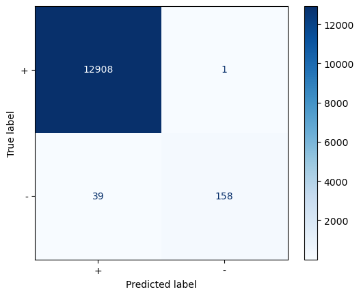

```python
from sklearn.metrics import ConfusionMatrixDisplay
import numpy as np

print('Training accuracy is %f' % accuracy_score(Y_train, Y_predTrain))
print('Validation accuracy is %f' %accuracy_score(Y_test, Y_predTest))
print('Training precision is %f' % precision_score(Y_train, Y_predTrain))
print('Validation precision is %f' % precision_score(Y_test, Y_predTest))
print('Training recall is %f' % recall_score(Y_train, Y_predTrain))
print('Validation recall is %f' % recall_score(Y_test, Y_predTest))
print('Training F-score is %f' % f1_score(Y_train, Y_predTrain))
print('Validation F-score %f' % f1_score(Y_test, Y_predTest))

disp = ConfusionMatrixDisplay.from_estimator(clf1, X_test, Y_test,display_labels=['+','-'],values_format = '.0f',cmap=plt.cm.Blues)
np.set_printoptions(precision=1)
print(disp.confusion_matrix)
```

#### 1.3 Bagging

```python
from sklearn.ensemble import BaggingClassifier
np.random.seed(1)
clf2 = BaggingClassifier(DecisionTreeClassifier(max_depth=2),n_estimators=50) # number estimators is the key parameter
clf2 = clf2.fit(X_train, Y_train)
Y_predTrain = clf2.predict(X_train)
Y_predTest = clf2.predict(X_test)
```

```
Training accuracy is 0.999491
Validation accuracy is 0.999695
Training precision is 0.993080
Validation precision is 0.994872
Training recall is 0.972881
Validation recall is 0.984772
Training F-score is 0.982877
Validation F-score 0.989796
[[12908     1]
 [    3   194]]
```

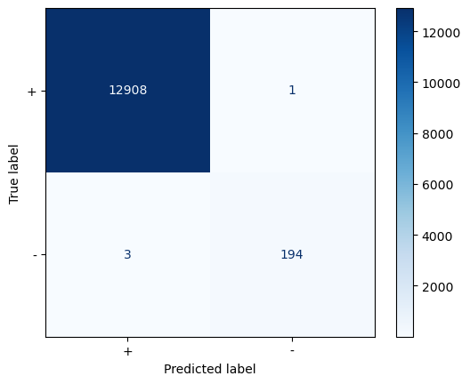

```python
from sklearn.metrics import ConfusionMatrixDisplay
import numpy as np

print('Training accuracy is %f' % accuracy_score(Y_train, Y_predTrain))
print('Validation accuracy is %f' %accuracy_score(Y_test, Y_predTest))
print('Training precision is %f' % precision_score(Y_train, Y_predTrain))
print('Validation precision is %f' % precision_score(Y_test, Y_predTest))
print('Training recall is %f' % recall_score(Y_train, Y_predTrain))
print('Validation recall is %f' % recall_score(Y_test, Y_predTest))
print('Training F-score is %f' % f1_score(Y_train, Y_predTrain))
print('Validation F-score %f' % f1_score(Y_test, Y_predTest))

disp = ConfusionMatrixDisplay.from_estimator(clf2, X_test, Y_test,display_labels=['+','-'],values_format = '.0f',cmap=plt.cm.Blues)
np.set_printoptions(precision=1)
print(disp.confusion_matrix)
```

#### 1.4 AdaBoost

```python
from sklearn.ensemble import AdaBoostClassifier
np.random.seed(1)
clf3 = AdaBoostClassifier(DecisionTreeClassifier(max_depth=2),n_estimators=5) # number estimators is the key parameter
clf3 = clf3.fit(X_train, Y_train)
Y_predTrain = clf3.predict(X_train)
Y_predTest = clf3.predict(X_test)
```

```
Training accuracy is 0.999593
Validation accuracy is 0.999542
Training precision is 0.996540
Validation precision is 0.989744
Training recall is 0.976271
Validation recall is 0.979695
Training F-score is 0.986301
Validation F-score 0.984694
[[12907     2]
 [    4   193]]
```

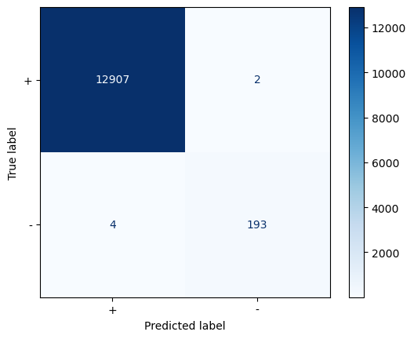

```python
from sklearn.metrics import ConfusionMatrixDisplay
import numpy as np

print('Training accuracy is %f' % accuracy_score(Y_train, Y_predTrain))
print('Validation accuracy is %f' %accuracy_score(Y_test, Y_predTest))
print('Training precision is %f' % precision_score(Y_train, Y_predTrain))
print('Validation precision is %f' % precision_score(Y_test, Y_predTest))
print('Training recall is %f' % recall_score(Y_train, Y_predTrain))
print('Validation recall is %f' % recall_score(Y_test, Y_predTest))
print('Training F-score is %f' % f1_score(Y_train, Y_predTrain))
print('Validation F-score %f' % f1_score(Y_test, Y_predTest))

disp = ConfusionMatrixDisplay.from_estimator(clf3, X_test, Y_test,display_labels=['+','-'],values_format = '.0f',cmap=plt.cm.Blues)
np.set_printoptions(precision=1)
print(disp.confusion_matrix)
```

#### 1.5 KNeighborsClassifier

```python
from sklearn.neighbors import KNeighborsClassifier
clf4=KNeighborsClassifier(3)
clf4 = clf4.fit(X_train, Y_train)
Y_predTrain = clf4.predict(X_train)
Y_predTest = clf4.predict(X_test)
```

```
Training accuracy is 0.998983
Validation accuracy is 0.998627
Training precision is 0.996390
Validation precision is 1.000000
Training recall is 0.935593
Validation recall is 0.908629
Training F-score is 0.965035
Validation F-score 0.952128
[[12909     0]
 [   18   179]]
```

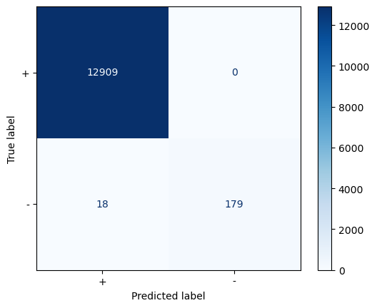

```python
from sklearn.metrics import ConfusionMatrixDisplay
import numpy as np

print('Training accuracy is %f' % accuracy_score(Y_train, Y_predTrain))
print('Validation accuracy is %f' %accuracy_score(Y_test, Y_predTest))
print('Training precision is %f' % precision_score(Y_train, Y_predTrain))
print('Validation precision is %f' % precision_score(Y_test, Y_predTest))
print('Training recall is %f' % recall_score(Y_train, Y_predTrain))
print('Validation recall is %f' % recall_score(Y_test, Y_predTest))
print('Training F-score is %f' % f1_score(Y_train, Y_predTrain))
print('Validation F-score %f' % f1_score(Y_test, Y_predTest))

disp = ConfusionMatrixDisplay.from_estimator(clf4, X_test, Y_test,display_labels=['+','-'],values_format = '.0f',cmap=plt.cm.Blues)
np.set_printoptions(precision=1)
print(disp.confusion_matrix)
```